# Short Introduction to R Commands

> **This Jupyter Notebook (JN) was built as a SJSU/GeneLab collaboration to introduce students to running R commands within a Jupyter environment. Many essential bioinformatics tools are written and run in the R language, including the tools we will use for differential gene expression analysis of RNA sequence data.**
- 0. What is R?
- 1. Introduction to programming in R
  - 1a. Install and load packages/libraries in R
  - 1b. Define locations and assign variables in R
  - 1c. Loading and viewing a data file in R
    - help()
    - read.csv()
    - head()
    - dim()
    - summary()
  - 1d. Data frame manipulations
    - Add a value to all cells
    - Take the log of all cells
    - Convert data frame to contain only integers
    - Slice a data frame column
    - Slice a data frame row
    - Filter data in a data frame
    - Add columns to a data frame
    - Combine data frames
  - 1e. Export data from R
  - 1f. Visualizations

# 0. What is R?

R is a programming language designed specifically for statistical analysis and computing. R has many bioinformatic libraries for statistical analysis, as well as for data visualization.

This Jupyter Notebook (JN) is running an R kernel, which means that each cell is designed to interpret and run commands written in the R language. A JN cannot run both an R kernel and a Python kernel at the same time.

Which language did we use when running Unix commands in the previous JN?

# 1. Introduction to programming in R

## 1a. Install and load packages/libraries in R

A R library, or package, is a collection of functions, compiled code, and sample data. Some R packages are installed automatically with the base R installation. But there are hundreds of packages that do not come with the base installation. If you want to use one of these packages, you can install it using the `install.packages()` function and then load it using the `library()` function.

For example, the following is the syntax to install the BiocManager package, which is then itself used to install any package from the Bioconductor suite.

`install.packages("BiocManager")`

Bioconductor packages including DESeq2, which we will use for differential gene expression analysis, are installed using the BiocManager `install()` function (instead of the R basic `install.packages()` function) and loaded using the R `library()` function as shown in the example below:

`BiocManager::install("DESeq2")`

`library(DESeq2)`

## 1b. Define locations and assign variables in R

#### getwd() and setwd()

The `getwd()` function in R stands for "get working directory". This function lists your current working directory, and is similar to the `pwd` command in Unix.

The `setwd()` function in R stands for "set working directory". This function allows you to change your current working directory, and is similar to the `cd` command in Unix.

Let's run `getwd()` in the next cell to print your current working directory.

```r
getwd()
```

'/home/jovyan'

Where are you located within the cluster?

Notice that the output of `getwd()` has quotation marks around it. That is because R is treating the path as a **string**, which is a one-dimensional array of characters that only represents the textual information contained between the quotation marks.

For example, 'Sally Ride was the first female American astronaut to go into space on June 18, 1983' is a string.

In the next cell, try running `setwd()` to change your current working directory to the `SolarSystem` folder you made in the Unix Intro JN (hint: the `SolarSystem` folder is located in your home directory). Then, run `getwd()` to check if you were successful.

- Remember that R expects paths as **strings**, so be sure to pass your path to `setwd()` as a string.

```r
setwd('/home/jovyan/SolarSystem')
```

```r
getwd()
```

'/home/jovyan/SolarSystem'

Next, use `setwd()` to change your working directory back to your home directory, then use `getwd()` to check if you navigated back successfully.

```r
setwd('/home/jovyan')
```

```r
getwd()
```

'/home/jovyan'

#### Assign variables in R

In most programming languages, including R, we use **variables** to store information. Variables are named objects which refer to data stored in memory. In R, we use the `<-` operator to assign information to a variable. Remember that it is very important to choose informative, memorable and short variable names.

For example, in the next cell, we are going to use the variable `x` to refer to the result of the equation `2+4`.

```r
x <- 2+4
```

We can access the data stored in the variable `x` using the function `print()`:

```r
print(x)
```

```
[1] 6
```

One of the cool things about the Jupyter environment is that the `print()` function is built-in, and we can access data stored in a variable simply by typing the variable name into a cell and running it:

```r
x
```

6

We can use variables to hold paths to locations so that we don't have to type out the path every time. Run the cell below to assign your home directory to the `homeDir` variable. We chose the `homeDir` variable as a short representation of the phrase "home directory".

```r
homeDir <- '/home/jovyan'
```

Use the next cell to print the content of the `homeDir` variable. Did you assign your variable successfully?

```r
homeDir
```

'/home/jovyan'

We can also use variables to store large amounts of data, such as assigning data within a matrix to a variable as you'll see in the next section.

**WARNING:** Never name your variable after a common function or a built-in variable in R. For a list of built-in R functions and variables, see "Appendix D Function and variable index" of the [R manual](https://cran.r-project.org/doc/manuals/r-release/R-intro.pdf).

## 1c. Loading and viewing a data file in R

To begin working with a data file in R, we first have to load (aka read in) the file. How you load the data file in R will depend on the file type. R has several built-in functions for reading in common file types, including .TXT files, .CSV (comma-separated values) files and .TSV (tab-separated-values) files.

In this tutorial, we are going to read in a .CSV file.

To do this, we will use a R function called `read.csv()`, which is specifically designed to handle data in the .CSV format. This function will create a data frame, which is a very common data structure in R. **Note:** A data frame is similar to a matrix.

#### help()

Before reading in the .CSV file, we'll use the `help()` function in R to view all possible arguments for the `read.csv()` function. (Note: this is similar to the `--help` option that's used in most Unix commands).

> **After you run the `help()` command:** The output from this command is long, so when you are done reading it, you can comment out this command by adding `#` at the beginning of the line, and rerun the cell to hide the output.

```r
help(read.csv)
```

| read.table {utils} | R Documentation |
| --- | --- |

Data Input

Description

Reads a file in table format and creates a data frame from it, with cases corresponding to lines and variables to fields in the file.

Usage

```
read.table(file, header = FALSE, sep = "", quote = "\"'",
           dec = ".", numerals = c("allow.loss", "warn.loss", "no.loss"),
           row.names, col.names, as.is = !stringsAsFactors,
           na.strings = "NA", colClasses = NA, nrows = -1,
           skip = 0, check.names = TRUE, fill = !blank.lines.skip,
           strip.white = FALSE, blank.lines.skip = TRUE,
           comment.char = "#",
           allowEscapes = FALSE, flush = FALSE,
           stringsAsFactors = FALSE,
           fileEncoding = "", encoding = "unknown", text, skipNul = FALSE)

read.csv(file, header = TRUE, sep = ",", quote = "\"",
         dec = ".", fill = TRUE, comment.char = "", ...)

read.csv2(file, header = TRUE, sep = ";", quote = "\"",
          dec = ",", fill = TRUE, comment.char = "", ...)

read.delim(file, header = TRUE, sep = "\t", quote = "\"",
           dec = ".", fill = TRUE, comment.char = "", ...)

read.delim2(file, header = TRUE, sep = "\t", quote = "\"",
            dec = ",", fill = TRUE, comment.char = "", ...)
```

Arguments

| `file` | the name of the file which the data are to be read from. Each row of the table appears as one line of the file. If it does not contain an *absolute* path, the file name is *relative* to the current wo… |
| --- | --- |
| `header` | a logical value indicating whether the file contains the names of the variables as its first line. If missing, the value is determined from the file format: `header` is set to `TRUE` if and only if th… |
| `sep` | the field separator character. Values on each line of the file are separated by this character. If `sep = ""` (the default for `read.table`) the separator is ‘white space’, that is one or more spaces,… |
| `quote` | the set of quoting characters. To disable quoting altogether, use `quote = ""`. See `scan` for the behaviour on quotes embedded in quotes. Quoting is only considered for columns read as character, whi… |
| `dec` | the character used in the file for decimal points. |
| `numerals` | string indicating how to convert numbers whose conversion to double precision would lose accuracy, see `type.convert`. Can be abbreviated. (Applies also to complex-number inputs.) |
| `row.names` | a vector of row names. This can be a vector giving the actual row names, or a single number giving the column of the table which contains the row names, or character string giving the name of the tabl… |
| `col.names` | a vector of optional names for the variables. The default is to use `"V"` followed by the column number. |
| `as.is` | controls conversion of character variables (insofar as they are not converted to logical, numeric or complex) to factors, if not otherwise specified by `colClasses`. Its value is either a vector of lo… |
| `na.strings` | a character vector of strings which are to be interpreted as `NA` values. Blank fields are also considered to be missing values in logical, integer, numeric and complex fields. Note that the test happ… |
| `colClasses` | character. A vector of classes to be assumed for the columns. If unnamed, recycled as necessary. If named, names are matched with unspecified values being taken to be `NA`. Possible values are `NA` (t… |
| `nrows` | integer: the maximum number of rows to read in. Negative and other invalid values are ignored. |
| `skip` | integer: the number of lines of the data file to skip before beginning to read data. |
| `check.names` | logical. If `TRUE` then the names of the variables in the data frame are checked to ensure that they are syntactically valid variable names. If necessary they are adjusted (by `make.names`) so that th… |
| `fill` | logical. If `TRUE` then in case the rows have unequal length, blank fields are implicitly added. See ‘Details’. |
| `strip.white` | logical. Used only when `sep` has been specified, and allows the stripping of leading and trailing white space from unquoted `character` fields (`numeric` fields are always stripped). See `scan` for f… |
| `blank.lines.skip` | logical: if `TRUE` blank lines in the input are ignored. |
| `comment.char` | character: a character vector of length one containing a single character or an empty string. Use `""` to turn off the interpretation of comments altogether. |
| `allowEscapes` | logical. Should C-style escapes such as \n be processed or read verbatim (the default)? Note that if not within quotes these could be interpreted as a delimiter (but not as a comment character). For m… |
| `flush` | logical: if `TRUE`, `scan` will flush to the end of the line after reading the last of the fields requested. This allows putting comments after the last field. |
| `stringsAsFactors` | logical: should character vectors be converted to factors? Note that this is overridden by `as.is` and `colClasses`, both of which allow finer control. |
| `fileEncoding` | character string: if non-empty declares the encoding used on a file (not a connection) so the character data can be re-encoded. See the ‘Encoding’ section of the help for `file`, the ‘R Data Import/Ex… |
| `encoding` | encoding to be assumed for input strings. It is used to mark character strings as known to be in Latin-1 or UTF-8 (see `Encoding`): it is not used to re-encode the input, but allows **R** to handle en… |
| `text` | character string: if `file` is not supplied and this is, then data are read from the value of `text` via a text connection. Notice that a literal string can be used to include (small) data sets within… |
| `skipNul` | logical: should nuls be skipped? |
| `...` | Further arguments to be passed to `read.table`. |

Details

This function is the principal means of reading tabular data into **R**.

Unless `colClasses` is specified, all columns are read as character columns and then converted using `type.convert` to logical, integer, numeric, complex or (depending on `as.is`) factor as appropriate. Quotes are (by default) interpreted in all fields, so a column of values like `"42"` will result in an integer column.

A field or line is ‘blank’ if it contains nothing (except whitespace if no separator is specified) before a comment character or the end of the field or line.

If `row.names` is not specified and the header line has one less entry than the number of columns, the first column is taken to be the row names. This allows data frames to be read in from the format in which they are printed. If `row.names` is specified and does not refer to the first column, that column is discarded from such files.

The number of data columns is determined by looking at the first five lines of input (or the whole input if it has less than five lines), or from the length of `col.names` if it is specified and is longer. This could conceivably be wrong if `fill` or `blank.lines.skip` are true, so specify `col.names` if necessary (as in the ‘Examples’).

`read.csv` and `read.csv2` are identical to `read.table` except for the defaults. They are intended for reading ‘comma separated value’ files (‘.csv’) or (`read.csv2`) the variant used in countries that use a comma as decimal point and a semicolon as field separator. Similarly, `read.delim` and `read.delim2` are for reading delimited files, defaulting to the TAB character for the delimiter. Notice that `header = TRUE` and `fill = TRUE` in these variants, and that the comment character is disabled.

The rest of the line after a comment character is skipped; quotes are not processed in comments. Complete comment lines are allowed provided `blank.lines.skip = TRUE`; however, comment lines prior to the header must have the comment character in the first non-blank column.

Quoted fields with embedded newlines are supported except after a comment character. Embedded nuls are unsupported: skipping them (with `skipNul = TRUE`) may work.

Value

A data frame (`data.frame`) containing a representation of the data in the file.

Empty input is an error unless `col.names` is specified, when a 0-row data frame is returned: similarly giving just a header line if `header = TRUE` results in a 0-row data frame. Note that in either case the columns will be logical unless `colClasses` was supplied.

Character strings in the result (including factor levels) will have a declared encoding if `encoding` is `"latin1"` or `"UTF-8"`.

CSV files

See the help on `write.csv` for the various conventions for `.csv` files. The commonest form of CSV file with row names needs to be read with `read.csv(..., row.names = 1)` to use the names in the first columnn of the file as row names.

Memory usage

These functions can use a surprising amount of memory when reading large files. There is extensive discussion in the ‘R Data Import/Export’ manual, supplementing the notes here.

Less memory will be used if `colClasses` is specified as one of the six atomic vector classes. This can be particularly so when reading a column that takes many distinct numeric values, as storing each distinct value as a character string can take up to 14 times as much memory as storing it as an integer.

Using `nrows`, even as a mild over-estimate, will help memory usage.

Using `comment.char = ""` will be appreciably faster than the `read.table` default.

`read.table` is not the right tool for reading large matrices, especially those with many columns: it is designed to read *data frames* which may have columns of very different classes. Use `scan` instead for matrices.

Note

The columns referred to in `as.is` and `colClasses` include the column of row names (if any).

There are two approaches for reading input that is not in the local encoding. If the input is known to be UTF-8 or Latin1, use the `encoding` argument to declare that. If the input is in some other encoding, then it may be translated on input. The `fileEncoding` argument achieves this by setting up a connection to do the re-encoding into the current locale. Note that on Windows or other systems not running in a UTF-8 locale, this may not be possible.

References

Chambers, J. M. (1992) *Data for models.* Chapter 3 of *Statistical Models in S* eds J. M. Chambers and T. J. Hastie, Wadsworth & Brooks/Cole.

See Also

The ‘R Data Import/Export’ manual.

`scan`, `type.convert`, `read.fwf` for reading *f*ixed *w*idth *f*ormatted input; `write.table`; `data.frame`.

`count.fields` can be useful to determine problems with reading files which result in reports of incorrect record lengths (see the ‘Examples’ below).

https://tools.ietf.org/html/rfc4180 for the IANA definition of CSV files (which requires comma as separator and CRLF line endings).

Examples

```
## using count.fields to handle unknown maximum number of fields
## when fill = TRUE
test1 <- c(1:5, "6,7", "8,9,10")
tf <- tempfile()
writeLines(test1, tf)

read.csv(tf, fill = TRUE) # 1 column
ncol <- max(count.fields(tf, sep = ","))
read.csv(tf, fill = TRUE, header = FALSE,
         col.names = paste0("V", seq_len(ncol)))
unlink(tf)

## "Inline" data set, using text=
## Notice that leading and trailing empty lines are auto-trimmed

read.table(header = TRUE, text = "
a b
1 2
3 4
")
```

[Package *utils* version 4.1.1 ]

#### read.csv()

Notice that to run `read.csv()`, we'll have to provide the function with a set of arguments. These arguments allow you to give R some information about the data in your .CSV file. Each possible argument is separated by a `,` (note: all arguments listed for the `read.table()` function can also be used in the `read.csv()` function). The arguments specified for `read.csv()` are the default argument settings.

In this tutorial, we are going to provide `read.csv()` with the following arguments:

- `example.csv` – the name of the file we want to read in
- `header=TRUE` – this argument specifies that the data starts on the second line of the file and the first line is a header, or column names
- `row.names=1` – this argument specifies that the data starts on the second column of the file and the first column contains row names

In the next cell, we will read in the `example.csv` file, and store the data frame in the variable `myDF`. We chose the variable `myDF` as a short representation of the phrase "my data frame".

```r
myDF <- read.csv('example.csv', header=TRUE, row.names=1)
```

Since the `example.csv` file is in your home directory, which is also your current working directory, you did not need to specify a path to the file you read in. However, if the file you want to read in is located in a directory other than your working directory, you would have to define the path to the directory that holds your file.

If the directory location of the file is held in a variable (as with your home directory in section 1b), you can use the function `file.path()` to construct the path to the file from the directory variable and the filename.

For example, since you stored the path to your home directory in the `homeDir` variable, you could have also read in the `example.csv` file using the following syntax:

`myDF <- read.csv(file.path(homeDir, 'example.csv'), header=TRUE, row.names=1)`

Use the next cell to view the data stored in the `myDF` variable.

```r
myDF
```

A data.frame: 10 × 3

|  | column1 <int> | column2 <int> | column3 <int> |
| --- | --- | --- | --- |
| row1 | 1 | 2 | 3 |
| row2 | 4 | 5 | 6 |
| row3 | 7 | 8 | 9 |
| row4 | 10 | 11 | 12 |
| row5 | 13 | 14 | 15 |
| row6 | 16 | 17 | 18 |
| row7 | 19 | 20 | 21 |
| row8 | 22 | 23 | 24 |
| row9 | 25 | 26 | 27 |
| row10 | 0 | 0 | 0 |

How many columns are in the `myDF` data frame?

How many rows?

#### head()

Although in this example there is a manageable amount of data in `myDF`, when working with a data frame containing RNA sequence data, viewing all the data may be unfeasible. Thus, similar to the `head` command in Unix, R also has a built-in function to view only a certain number of rows of a data frame or matrix, called `head()`.

In the next cell, run `head()` and provide only one argument, the data frame variable.

```r
head(myDF)
```

A data.frame: 6 × 3

|  | column1 <int> | column2 <int> | column3 <int> |
| --- | --- | --- | --- |
| row1 | 1 | 2 | 3 |
| row2 | 4 | 5 | 6 |
| row3 | 7 | 8 | 9 |
| row4 | 10 | 11 | 12 |
| row5 | 13 | 14 | 15 |
| row6 | 16 | 17 | 18 |

How many lines are given with the `head()` command in R? Is this different from the number of lines given with the `head` command in Unix?

We can also specify the number of lines we want to view, by providing `head()` with another argument, `n=3`:

```r
head(myDF, n=3)
```

A data.frame: 3 × 3

|  | column1 <int> | column2 <int> | column3 <int> |
| --- | --- | --- | --- |
| row1 | 1 | 2 | 3 |
| row2 | 4 | 5 | 6 |
| row3 | 7 | 8 | 9 |

Use the next cell to print the first 8 rows of the `myDF` data frame.

```r
head(myDF, n=8)
```

A data.frame: 8 × 3

|  | column1 <int> | column2 <int> | column3 <int> |
| --- | --- | --- | --- |
| row1 | 1 | 2 | 3 |
| row2 | 4 | 5 | 6 |
| row3 | 7 | 8 | 9 |
| row4 | 10 | 11 | 12 |
| row5 | 13 | 14 | 15 |
| row6 | 16 | 17 | 18 |
| row7 | 19 | 20 | 21 |
| row8 | 22 | 23 | 24 |

#### dim()

R also has a funtion called `dim()` that will allow you to print the dimensions of the data frame without having to print any lines.

In the next cell, you will use the `dim()` function to report the *dimensions*, or number of rows and columns, of your `myDF` data frame.

```r
dim(myDF)
```

1. 10

2. 3

Is the row or column dimension reported first?

How many rows does `myDF` have? How many columns?

#### summary()

To get more information about a loaded data frame without having to print the entire data frame, we can use the `summary()` function in R, which will print a mathematical summary of the data frame. Note: `summary()` can also be used on non-data frame objects to report all the data components contained in the object.

Run the `summary()` function in the next cell to view a mathematical summary of your `myDF` data frame.

```r
summary(myDF)
```

```
    column1         column2         column3
 Min.   : 0.00   Min.   : 0.00   Min.   : 0.00
 1st Qu.: 4.75   1st Qu.: 5.75   1st Qu.: 6.75
 Median :11.50   Median :12.50   Median :13.50
 Mean   :11.70   Mean   :12.60   Mean   :13.50
 3rd Qu.:18.25   3rd Qu.:19.25   3rd Qu.:20.25
 Max.   :25.00   Max.   :26.00   Max.   :27.00
```

Which column contains the highest median value in the data frame, `myDF`? Which column contains the highest overall value?

## 1d. Data frame manipulations

Much of the data we work with in bioinformatics is in the data frame or matrix format. For example, gene expression data is usually held in matrix format, with samples as columns and genes as rows. Each entry or cell in the matrix contains the expression of a particular gene in a particular sample.

When analyzing gene expression data, it can be useful to be able to perform mathematical functions on all cells in a data frame, such as adding a value to all cells or taking the log of all cells. Fortunately, R makes that easy for us to do.

Below are some examples of common mathematical manipulations we often perform on data frames in bioinformatics.

#### Add a value to all cells

In R, you can add, subtract, multiply, or divide the number in every cell of a data frame by a specific value very easily. Run the command in the next cell to add `1` to every value in your `myDF` data frame.

```r
myDF + 1
```

A data.frame: 10 × 3

|  | column1 <dbl> | column2 <dbl> | column3 <dbl> |
| --- | --- | --- | --- |
| row1 | 2 | 3 | 4 |
| row2 | 5 | 6 | 7 |
| row3 | 8 | 9 | 10 |
| row4 | 11 | 12 | 13 |
| row5 | 14 | 15 | 16 |
| row6 | 17 | 18 | 19 |
| row7 | 20 | 21 | 22 |
| row8 | 23 | 24 | 25 |
| row9 | 26 | 27 | 28 |
| row10 | 1 | 1 | 1 |

Use the next cell to subtract 2 from all values in your `myDF` data frame.

```r
myDF -2
```

A data.frame: 10 × 3

|  | column1 <dbl> | column2 <dbl> | column3 <dbl> |
| --- | --- | --- | --- |
| row1 | -1 | 0 | 1 |
| row2 | 2 | 3 | 4 |
| row3 | 5 | 6 | 7 |
| row4 | 8 | 9 | 10 |
| row5 | 11 | 12 | 13 |
| row6 | 14 | 15 | 16 |
| row7 | 17 | 18 | 19 |
| row8 | 20 | 21 | 22 |
| row9 | 23 | 24 | 25 |
| row10 | -2 | -2 | -2 |

#### Take the log of all cells

R also has a `log()` function that will allow you to take the log of all values in a data frame. By default, the `log()` function will calculate the natural log. However, you can specify which base you want to use as follows:

`log10()` will compute the common logarithm (base 10)

`log2()` will compute the binary logarithm (base 2)

Run the next cell to compute the natural logarithm of all values in your `myDF` data frame.

```r
log(myDF)
```

A data.frame: 10 × 3

|  | column1 <dbl> | column2 <dbl> | column3 <dbl> |
| --- | --- | --- | --- |
| row1 | 0.000000 | 0.6931472 | 1.098612 |
| row2 | 1.386294 | 1.6094379 | 1.791759 |
| row3 | 1.945910 | 2.0794415 | 2.197225 |
| row4 | 2.302585 | 2.3978953 | 2.484907 |
| row5 | 2.564949 | 2.6390573 | 2.708050 |
| row6 | 2.772589 | 2.8332133 | 2.890372 |
| row7 | 2.944439 | 2.9957323 | 3.044522 |
| row8 | 3.091042 | 3.1354942 | 3.178054 |
| row9 | 3.218876 | 3.2580965 | 3.295837 |
| row10 | -Inf | -Inf | -Inf |

Use the next cell to compute the binary logarithm of all values in your `myDF` data frame.

```r
log2(myDF)
```

A data.frame: 10 × 3

|  | column1 <dbl> | column2 <dbl> | column3 <dbl> |
| --- | --- | --- | --- |
| row1 | 0.000000 | 1.000000 | 1.584963 |
| row2 | 2.000000 | 2.321928 | 2.584963 |
| row3 | 2.807355 | 3.000000 | 3.169925 |
| row4 | 3.321928 | 3.459432 | 3.584963 |
| row5 | 3.700440 | 3.807355 | 3.906891 |
| row6 | 4.000000 | 4.087463 | 4.169925 |
| row7 | 4.247928 | 4.321928 | 4.392317 |
| row8 | 4.459432 | 4.523562 | 4.584963 |
| row9 | 4.643856 | 4.700440 | 4.754888 |
| row10 | -Inf | -Inf | -Inf |

#### Convert data frame to contain only integers

Some bioinformatics applications, including the DESeq2 method we will use to perform differential gene expression, require that the input data contain only integers. There is a function in R called `ceiling()` that will round decimal values up to the nearest integer.

Run the next cell to test the `ceiling()` function.

```r
ceiling(1.2)
```

2

Before we test this function on a data frame, we first have to create a data frame that contains decimal values. Note that although the `log()` function was used to print the natural logarithm of all values in your `myDF` data frame, those calculations were not saved in the `myDF` variable.

Use the next cell to print the data held in the `myDF` variable. Are the values indeed the same as what we started with?

```r
myDF
```

A data.frame: 10 × 3

|  | column1 <int> | column2 <int> | column3 <int> |
| --- | --- | --- | --- |
| row1 | 1 | 2 | 3 |
| row2 | 4 | 5 | 6 |
| row3 | 7 | 8 | 9 |
| row4 | 10 | 11 | 12 |
| row5 | 13 | 14 | 15 |
| row6 | 16 | 17 | 18 |
| row7 | 19 | 20 | 21 |
| row8 | 22 | 23 | 24 |
| row9 | 25 | 26 | 27 |
| row10 | 0 | 0 | 0 |

To make changes to your `myDF` variable, the calculations must be assigned to `myDF`. In the following cell, you will subtract 0.3 from all values in your `myDF` data frame and assign the new values back to the `myDF` variable.

```r
myDF <- myDF - 0.3
```

In the next cell, print the data held in the `myDF` variable. Have the values in `myDF` changed?

```r
myDF
```

A data.frame: 10 × 3

|  | column1 <dbl> | column2 <dbl> | column3 <dbl> |
| --- | --- | --- | --- |
| row1 | 0.7 | 1.7 | 2.7 |
| row2 | 3.7 | 4.7 | 5.7 |
| row3 | 6.7 | 7.7 | 8.7 |
| row4 | 9.7 | 10.7 | 11.7 |
| row5 | 12.7 | 13.7 | 14.7 |
| row6 | 15.7 | 16.7 | 17.7 |
| row7 | 18.7 | 19.7 | 20.7 |
| row8 | 21.7 | 22.7 | 23.7 |
| row9 | 24.7 | 25.7 | 26.7 |
| row10 | -0.3 | -0.3 | -0.3 |

Note: If you want to keep a variable containing the original data in the data frame and also preserve the calculations performed, you can assign the calculations performed on `myDF` to a different variable as follows: `myDFsub <- myDF - 0.3`

Now that your `myDF` data frame contains decimal values, use the `ceiling()` function to round all the values in `myDF` up to the nearest integer, and assign the new values back to the `myDF` variable.

```r
myDF <- ceiling(myDF)
```

In the next cell, print the data held in the `myDF` variable. How have the values in `myDF` changed?

```r
myDF
```

A data.frame: 10 × 3

|  | column1 <dbl> | column2 <dbl> | column3 <dbl> |
| --- | --- | --- | --- |
| row1 | 1 | 2 | 3 |
| row2 | 4 | 5 | 6 |
| row3 | 7 | 8 | 9 |
| row4 | 10 | 11 | 12 |
| row5 | 13 | 14 | 15 |
| row6 | 16 | 17 | 18 |
| row7 | 19 | 20 | 21 |
| row8 | 22 | 23 | 24 |
| row9 | 25 | 26 | 27 |
| row10 | 0 | 0 | 0 |

##### Slice a data frame column

When analyzing bioinformatics data, you may need to extract only one column from a data frame. To subset a data frame based on column names, we use the bracket `[` operator. This type of operation is also referred to as "slicing" the data frame.

Run the cell below to slice `column1` of your `myDF` data frame.

```r
myDF['column1']
```

A data.frame: 10 × 1

|  | column1 <dbl> |
| --- | --- |
| row1 | 1 |
| row2 | 4 |
| row3 | 7 |
| row4 | 10 |
| row5 | 13 |
| row6 | 16 |
| row7 | 19 |
| row8 | 22 |
| row9 | 25 |
| row10 | 0 |

**Challenge:** In the next cell, try subsetting `myDF` to "column2", but only view the first 3 rows of the output using `head()`.

```r
head(myDF['column2'])
```

A data.frame: 6 × 1

|  | column2 <dbl> |
| --- | --- |
| row1 | 2 |
| row2 | 5 |
| row3 | 8 |
| row4 | 11 |
| row5 | 14 |
| row6 | 17 |

#### Slice a data frame row

To subset a data frame based on row names, we again use the bracket `[` operator, but we add a comma after indicating the row name, which lets R know that we are slicing along rows instead of columns.

Run the cell below to slice `row1` of your `myDF` data frame.

```r
myDF['row1',]
```

A data.frame: 1 × 3

|  | column1 <dbl> | column2 <dbl> | column3 <dbl> |
| --- | --- | --- | --- |
| row1 | 1 | 2 | 3 |

#### Filter data in a data frame

When analyzing bioinformatics data, we often need to filter the data to reduce noise. A common filtering method is to remove rows that have all zero values. To do this, we will remove all rows whose values sum to zero using a function called `rowSums()`.

First let's calculate the sum of each row in your `myDF` data frame using the `rowSums()` function:

```r
rowSums(myDF)
```

**row1**

6

**row2**

15

**row3**

24

**row4**

33

**row5**

42

**row6**

51

**row7**

60

**row8**

69

**row9**

78

**row10**

0

Next, we'll use the greater than mathematical operator, `>`, to identify which rows have sums greater than zero:

```r
rowSums(myDF)>0
```

**row1**

TRUE

**row2**

TRUE

**row3**

TRUE

**row4**

TRUE

**row5**

TRUE

**row6**

TRUE

**row7**

TRUE

**row8**

TRUE

**row9**

TRUE

**row10**

FALSE

Finally, we can apply this output to subset the `myDF` data frame by removing all rows whose values sum to zero, using the same row slicing method we used above:

```r
myDF[ rowSums(myDF)>0 , ]
```

A data.frame: 9 × 3

|  | column1 <dbl> | column2 <dbl> | column3 <dbl> |
| --- | --- | --- | --- |
| row1 | 1 | 2 | 3 |
| row2 | 4 | 5 | 6 |
| row3 | 7 | 8 | 9 |
| row4 | 10 | 11 | 12 |
| row5 | 13 | 14 | 15 |
| row6 | 16 | 17 | 18 |
| row7 | 19 | 20 | 21 |
| row8 | 22 | 23 | 24 |
| row9 | 25 | 26 | 27 |

Use what you've just learned to remove all rows in `myDF` whose sum is less than 20, in the next cell.

```r
myDF[ rowSums(myDF)>20 , ]
```

A data.frame: 7 × 3

|  | column1 <dbl> | column2 <dbl> | column3 <dbl> |
| --- | --- | --- | --- |
| row3 | 7 | 8 | 9 |
| row4 | 10 | 11 | 12 |
| row5 | 13 | 14 | 15 |
| row6 | 16 | 17 | 18 |
| row7 | 19 | 20 | 21 |
| row8 | 22 | 23 | 24 |
| row9 | 25 | 26 | 27 |

#### Add columns to a data frame

When generating a table containing results from a bioinformatic analysis, it may be useful to add a column. To add a column to a data frame, we use the `[` bracket operator to name the new column. We then turn the new column into a variable using the `<-` operator, and we assign a list of values to that variable.

To create a list of values in R, we use the `c()` function, which is a method that combines all its arguments to form a vector, or list.

Run the next cell to add a 4th column to your `myDF` data frame, then print the revised data frame, `myDF`.

```r
myDF['column4'] <- c(1,2,3,4,5,6,7,8,9,10)
myDF
```

A data.frame: 10 × 4

|  | column1 <dbl> | column2 <dbl> | column3 <dbl> | column4 <dbl> |
| --- | --- | --- | --- | --- |
| row1 | 1 | 2 | 3 | 1 |
| row2 | 4 | 5 | 6 | 2 |
| row3 | 7 | 8 | 9 | 3 |
| row4 | 10 | 11 | 12 | 4 |
| row5 | 13 | 14 | 15 | 5 |
| row6 | 16 | 17 | 18 | 6 |
| row7 | 19 | 20 | 21 | 7 |
| row8 | 22 | 23 | 24 | 8 |
| row9 | 25 | 26 | 27 | 9 |
| row10 | 0 | 0 | 0 | 10 |

Use the next cell to add a 5th column to your `myDF` data frame, then print the revised data frame.

```r
myDF['column5'] <- c(2,4,6,8,10,12,14,16,18,20)
myDF
```

A data.frame: 10 × 5

|  | column1 <dbl> | column2 <dbl> | column3 <dbl> | column4 <dbl> | column5 <dbl> |
| --- | --- | --- | --- | --- | --- |
| row1 | 1 | 2 | 3 | 1 | 2 |
| row2 | 4 | 5 | 6 | 2 | 4 |
| row3 | 7 | 8 | 9 | 3 | 6 |
| row4 | 10 | 11 | 12 | 4 | 8 |
| row5 | 13 | 14 | 15 | 5 | 10 |
| row6 | 16 | 17 | 18 | 6 | 12 |
| row7 | 19 | 20 | 21 | 7 | 14 |
| row8 | 22 | 23 | 24 | 8 | 16 |
| row9 | 25 | 26 | 27 | 9 | 18 |
| row10 | 0 | 0 | 0 | 10 | 20 |

#### Combine data frames

Sometimes in bioinformatics, we have two (or more) data frames that we want to combine into one data frame. To do this, we can use the R function `cbind()`. `cbind()` requires at least two arguments: the names of the two data frames that need to be combined.

Let's duplicate `myDF` and then use `cbind()` to merge the original and duplicated data frames.

Run the following cell to create a copy of `myDF` in a variable called `myDF2`, then view the contents of the `myDF2` data frame.

```r
myDF2 <- myDF
myDF2
```

A data.frame: 10 × 5

|  | column1 <dbl> | column2 <dbl> | column3 <dbl> | column4 <dbl> | column5 <dbl> |
| --- | --- | --- | --- | --- | --- |
| row1 | 1 | 2 | 3 | 1 | 2 |
| row2 | 4 | 5 | 6 | 2 | 4 |
| row3 | 7 | 8 | 9 | 3 | 6 |
| row4 | 10 | 11 | 12 | 4 | 8 |
| row5 | 13 | 14 | 15 | 5 | 10 |
| row6 | 16 | 17 | 18 | 6 | 12 |
| row7 | 19 | 20 | 21 | 7 | 14 |
| row8 | 22 | 23 | 24 | 8 | 16 |
| row9 | 25 | 26 | 27 | 9 | 18 |
| row10 | 0 | 0 | 0 | 10 | 20 |

Now that we have two data frames, `myDF` and `myDF2`, let's use `cbind()` to combine them into one data frame:

```r
cbind(myDF, myDF2)
```

A data.frame: 10 × 10

|  | column1 <dbl> | column2 <dbl> | column3 <dbl> | column4 <dbl> | column5 <dbl> | column1 <dbl> | column2 <dbl> | column3 <dbl> | column4 <dbl> | column5 <dbl> |
| --- | --- | --- | --- | --- | --- | --- | --- | --- | --- | --- |
| row1 | 1 | 2 | 3 | 1 | 2 | 1 | 2 | 3 | 1 | 2 |
| row2 | 4 | 5 | 6 | 2 | 4 | 4 | 5 | 6 | 2 | 4 |
| row3 | 7 | 8 | 9 | 3 | 6 | 7 | 8 | 9 | 3 | 6 |
| row4 | 10 | 11 | 12 | 4 | 8 | 10 | 11 | 12 | 4 | 8 |
| row5 | 13 | 14 | 15 | 5 | 10 | 13 | 14 | 15 | 5 | 10 |
| row6 | 16 | 17 | 18 | 6 | 12 | 16 | 17 | 18 | 6 | 12 |
| row7 | 19 | 20 | 21 | 7 | 14 | 19 | 20 | 21 | 7 | 14 |
| row8 | 22 | 23 | 24 | 8 | 16 | 22 | 23 | 24 | 8 | 16 |
| row9 | 25 | 26 | 27 | 9 | 18 | 25 | 26 | 27 | 9 | 18 |
| row10 | 0 | 0 | 0 | 10 | 20 | 0 | 0 | 0 | 10 | 20 |

Now, instead of merely printing the combined data frame, use the next cell to create a variable called `combinedDF` that holds the combined data frame. We suggest the `combinedDF` as a short representation of the phrase "combined data frame".

```r
combinedDF <- cbind(myDF, myDF2)
```

What are the dimensions of the `combinedDF` data frame? Hint: use the `dim()` function in the cell below.

```r
dim(combinedDF)
```

1. 10

2. 10

Did `cbind()` merge these data frames on the row dimension or the column dimension? Why do you think that is? Hint: you can take a look at the `cbind()` documentation using the `help()` function.

```r
help('cbind')
```

| cbind {base} | R Documentation |
| --- | --- |

Combine R Objects by Rows or Columns

Description

Take a sequence of vector, matrix or data-frame arguments and combine by *c*olumns or *r*ows, respectively. These are generic functions with methods for other **R** classes.

Usage

```
cbind(..., deparse.level = 1)
rbind(..., deparse.level = 1)
## S3 method for class 'data.frame'
rbind(..., deparse.level = 1, make.row.names = TRUE,
      stringsAsFactors = FALSE, factor.exclude = TRUE)
```

Arguments

| `...` | (generalized) vectors or matrices. These can be given as named arguments. Other **R** objects may be coerced as appropriate, or S4 methods may be used: see sections ‘Details’ and ‘Value’. (For the `"d… |
| --- | --- |
| `deparse.level` | integer controlling the construction of labels in the case of non-matrix-like arguments (for the default method): `deparse.level = 0` constructs no labels; the default, `deparse.level = 1 or 2` constr… |
| `make.row.names` | (only for data frame method:) logical indicating if unique and valid `row.names` should be constructed from the arguments. |
| `stringsAsFactors` | logical, passed to `as.data.frame`; only has an effect when the `...` arguments contain a (non-`data.frame`) `character`. |
| `factor.exclude` | if the data frames contain factors, the default `TRUE` ensures that `NA` levels of factors are kept, see [PR#17562](https://bugs.R-project.org/bugzilla3/show_bug.cgi?id=17562) and the ‘Data frame meth… |

Details

The functions `cbind` and `rbind` are S3 generic, with methods for data frames. The data frame method will be used if at least one argument is a data frame and the rest are vectors or matrices. There can be other methods; in particular, there is one for time series objects. See the section on ‘Dispatch’ for how the method to be used is selected. If some of the arguments are of an S4 class, i.e., `isS4(.)` is true, S4 methods are sought also, and the hidden `cbind` / `rbind` functions from package methods maybe called, which in turn build on `cbind2` or `rbind2`, respectively. In that case, `deparse.level` is obeyed, similarly to the default method.

In the default method, all the vectors/matrices must be atomic (see `vector`) or lists. Expressions are not allowed. Language objects (such as formulae and calls) and pairlists will be coerced to lists: other objects (such as names and external pointers) will be included as elements in a list result. Any classes the inputs might have are discarded (in particular, factors are replaced by their internal codes).

If there are several matrix arguments, they must all have the same number of columns (or rows) and this will be the number of columns (or rows) of the result. If all the arguments are vectors, the number of columns (rows) in the result is equal to the length of the longest vector. Values in shorter arguments are recycled to achieve this length (with a `warning` if they are recycled only *fractionally*).

When the arguments consist of a mix of matrices and vectors the number of columns (rows) of the result is determined by the number of columns (rows) of the matrix arguments. Any vectors have their values recycled or subsetted to achieve this length.

For `cbind` (`rbind`), vectors of zero length (including `NULL`) are ignored unless the result would have zero rows (columns), for S compatibility. (Zero-extent matrices do not occur in S3 and are not ignored in **R**.)

Matrices are restricted to less than *2^31* rows and columns even on 64-bit systems. So input vectors have the same length restriction: as from **R** 3.2.0 input matrices with more elements (but meeting the row and column restrictions) are allowed.

Value

For the default method, a matrix combining the `...` arguments column-wise or row-wise. (Exception: if there are no inputs or all the inputs are `NULL`, the value is `NULL`.)

The type of a matrix result determined from the highest type of any of the inputs in the hierarchy raw < logical < integer < double < complex < character < list .

For `cbind` (`rbind`) the column (row) names are taken from the `colnames` (`rownames`) of the arguments if these are matrix-like. Otherwise from the names of the arguments or where those are not supplied and `deparse.level > 0`, by deparsing the expressions given, for `deparse.level = 1` only if that gives a sensible name (a ‘symbol’, see `is.symbol`).

For `cbind` row names are taken from the first argument with appropriate names: rownames for a matrix, or names for a vector of length the number of rows of the result.

For `rbind` column names are taken from the first argument with appropriate names: colnames for a matrix, or names for a vector of length the number of columns of the result.

Data frame methods

The `cbind` data frame method is just a wrapper for `data.frame(..., check.names = FALSE)`. This means that it will split matrix columns in data frame arguments, and convert character columns to factors unless `stringsAsFactors = FALSE` is specified.

The `rbind` data frame method first drops all zero-column and zero-row arguments. (If that leaves none, it returns the first argument with columns otherwise a zero-column zero-row data frame.) It then takes the classes of the columns from the first data frame, and matches columns by name (rather than by position). Factors have their levels expanded as necessary (in the order of the levels of the level sets of the factors encountered) and the result is an ordered factor if and only if all the components were ordered factors. (The last point differs from S-PLUS.) Old-style categories (integer vectors with levels) are promoted to factors.

Note that for result column `j`, `factor(., exclude = X(j))` is applied, where

```
  X(j) := if(isTRUE(factor.exclude)) {
             if(!NA.lev[j]) NA # else NULL
          } else factor.exclude
```

where `NA.lev[j]` is true iff any contributing data frame has had a `factor` in column `j` with an explicit `NA` level.

Dispatch

The method dispatching is *not* done via `UseMethod()`, but by C-internal dispatching. Therefore there is no need for, e.g., `rbind.default`.

The dispatch algorithm is described in the source file (‘.../src/main/bind.c’) as

1. For each argument we get the list of possible class memberships from the class attribute.

2. We inspect each class in turn to see if there is an applicable method.

3. If we find a method, we use it. Otherwise, if there was an S4 object among the arguments, we try S4 dispatch; otherwise, we use the default code.

(Before **R** 4.0.0, an applicable method found was used only if identical to any method determined for prior arguments.)

If you want to combine other objects with data frames, it may be necessary to coerce them to data frames first. (Note that this algorithm can result in calling the data frame method if all the arguments are either data frames or vectors, and this will result in the coercion of character vectors to factors.)

References

Becker, R. A., Chambers, J. M. and Wilks, A. R. (1988) *The New S Language*. Wadsworth & Brooks/Cole.

See Also

`c` to combine vectors (and lists) as vectors, `data.frame` to combine vectors and matrices as a data frame.

Examples

```
m <- cbind(1, 1:7) # the '1' (= shorter vector) is recycled
m
m <- cbind(m, 8:14)[, c(1, 3, 2)] # insert a column
m
cbind(1:7, diag(3)) # vector is subset -> warning

cbind(0, rbind(1, 1:3))
cbind(I = 0, X = rbind(a = 1, b = 1:3))  # use some names
xx <- data.frame(I = rep(0,2))
cbind(xx, X = rbind(a = 1, b = 1:3))   # named differently

cbind(0, matrix(1, nrow = 0, ncol = 4)) #> Warning (making sense)
dim(cbind(0, matrix(1, nrow = 2, ncol = 0))) #-> 2 x 1

## deparse.level
dd <- 10
rbind(1:4, c = 2, "a++" = 10, dd, deparse.level = 0) # middle 2 rownames
rbind(1:4, c = 2, "a++" = 10, dd, deparse.level = 1) # 3 rownames (default)
rbind(1:4, c = 2, "a++" = 10, dd, deparse.level = 2) # 4 rownames

## cheap row names:
b0 <- gl(3,4, labels=letters[1:3])
bf <- setNames(b0, paste0("o", seq_along(b0)))
df  <- data.frame(a = 1, B = b0, f = gl(4,3))
df. <- data.frame(a = 1, B = bf, f = gl(4,3))
new <- data.frame(a = 8, B ="B", f = "1")
(df1  <- rbind(df , new))
(df.1 <- rbind(df., new))
stopifnot(identical(df1, rbind(df,  new, make.row.names=FALSE)),
          identical(df1, rbind(df., new, make.row.names=FALSE)))
```

[Package *base* version 4.1.1 ]

## 1e. Export data from R

#### write.csv()

Thus far, we have manipulated data frame variables in R, but the altered data is only stored in memory until you export it. How you export data in R will depend on the file type to which you want to export the data. Similar to loading data in R, R has several built-in functions for exporting common file types, including .TXT files, .CSV (comma-separated values) files and .TSV (tab-separated-values) files.

In this tutorial, we will export the data as a .CSV file. To do this, we will use the `write.csv()` function to write a data frame out to a file. The following arguments are needed to execute the `write.csv()` function:

- the data frame we want to write out
- the file name we want to write to

In the next cell, you will use `write.csv()` to export your `combinedDF` data frame to a file called `combinedDF.csv`.

```r
write.csv(combinedDF, 'combinedDF.csv')
```

List all files in your current directory using the `list.files()` function:

```r
list.files()
```

1. 'Bootcamp_content'

2. 'Bootcamp_content2'

3. 'combinedDF.csv'

4. 'efs'

5. 'example.csv'

6. 'example.txt'

7. 'lost+found'

8. 'Mars.txt'

9. 'myown_JNs'

10. 'R_Intro_JN_06-2022.ipynb'

11. 'RNAseq_DGE_JN_06-2022_wLRT.ipynb'

12. 'RNAseq_DGE_JN_06-2022.ipynb'

13. 'RNAseq_fastq_to_counts_JN_06-2022.ipynb'

14. 'Saturn_copy.txt'

15. 'Saturn.txt'

16. 'SolarSystem'

17. 'Unix_Intro_JN_06-2022.ipynb'

Do you see your `combinedDF.csv` file in your current directory?

Challenge: Use the next few cells to export your `myDF2` data frame as a .CSV file called `myDF2.csv` but this time, specify your home directory as the path you want to write your file to (hint: use the `homeDir` variable you created previously). Then list all files in your home directory. Did you successfully export the `myDF2.csv` file?

```r
write.csv(myDF2, 'myDF2.csv')
```

```r
list.files()
```

1. 'Bootcamp_content'

2. 'Bootcamp_content2'

3. 'combinedDF.csv'

4. 'efs'

5. 'example.csv'

6. 'example.txt'

7. 'lost+found'

8. 'Mars.txt'

9. 'myDF2.csv'

10. 'myown_JNs'

11. 'R_Intro_JN_06-2022.ipynb'

12. 'RNAseq_DGE_JN_06-2022_wLRT.ipynb'

13. 'RNAseq_DGE_JN_06-2022.ipynb'

14. 'RNAseq_fastq_to_counts_JN_06-2022.ipynb'

15. 'Saturn_copy.txt'

16. 'Saturn.txt'

17. 'SolarSystem'

18. 'Unix_Intro_JN_06-2022.ipynb'

## 1f. Visualizations

#### plot()

R has a basic built-in function for many common plot types called `plot()`.

At its most basic, the function call is: `plot(x,y)`, where x and y are numeric vectors containing the (x,y) points for the plot.

Let's call `plot()` with the following parameters:

- x = the values from myDF2, column 1
- y = the values from myDF2, column 4

We saw before that we can use the following syntax to extract just one column from a dataframe: `myDF2['column1']`. But recall that this produces a subset dataframe, not a vector of numbers.

If we need just the values from a column as a vector of numbers, we can use the following syntax: `myDF2$column1`

> Note: The `$` specifies the column title.

Use this syntax to fill in the x and y vectors in the function call below:

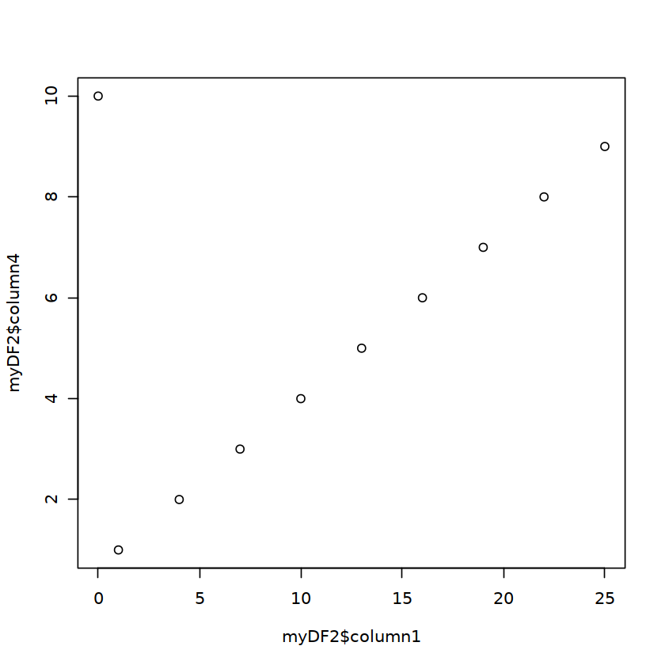

```r
plot(myDF2$column1,myDF2$column4)
```

Let's see if we can make this plot more interesting. Let's look at the parameters for `plot()`:

```r
help(plot)
```

| plot.default {graphics} | R Documentation |
| --- | --- |

The Default Scatterplot Function

Description

Draw a scatter plot with decorations such as axes and titles in the active graphics window.

Usage

```
## Default S3 method:
plot(x, y = NULL, type = "p",  xlim = NULL, ylim = NULL,
     log = "", main = NULL, sub = NULL, xlab = NULL, ylab = NULL,
     ann = par("ann"), axes = TRUE, frame.plot = axes,
     panel.first = NULL, panel.last = NULL, asp = NA,
     xgap.axis = NA, ygap.axis = NA,
     ...)
```

Arguments

| `x, y` | the `x` and `y` arguments provide the x and y coordinates for the plot. Any reasonable way of defining the coordinates is acceptable. See the function `xy.coords` for details. If supplied separately, … |
| --- | --- |
| `type` | 1-character string giving the type of plot desired. The following values are possible, for details, see `plot`: `"p"` for points, `"l"` for lines, `"b"` for both points and lines, `"c"` for empty poin… |
| `xlim` | the x limits (x1, x2) of the plot. Note that `x1 > x2` is allowed and leads to a ‘reversed axis’. The default value, `NULL`, indicates that the range of the finite values to be plotted should be used. |
| `ylim` | the y limits of the plot. |
| `log` | a character string which contains `"x"` if the x axis is to be logarithmic, `"y"` if the y axis is to be logarithmic and `"xy"` or `"yx"` if both axes are to be logarithmic. |
| `main` | a main title for the plot, see also `title`. |
| `sub` | a sub title for the plot. |
| `xlab` | a label for the x axis, defaults to a description of `x`. |
| `ylab` | a label for the y axis, defaults to a description of `y`. |
| `ann` | a logical value indicating whether the default annotation (title and x and y axis labels) should appear on the plot. |
| `axes` | a logical value indicating whether both axes should be drawn on the plot. Use graphical parameter `"xaxt"` or `"yaxt"` to suppress just one of the axes. |
| `frame.plot` | a logical indicating whether a box should be drawn around the plot. |
| `panel.first` | an ‘expression’ to be evaluated after the plot axes are set up but before any plotting takes place. This can be useful for drawing background grids or scatterplot smooths. Note that this works by lazy… |
| `panel.last` | an expression to be evaluated after plotting has taken place but before the axes, title and box are added. See the comments about `panel.first`. |
| `asp` | the *y/x* aspect ratio, see `plot.window`. |
| `xgap.axis, ygap.axis` | the *x/y* axis gap factors, passed as `gap.axis` to the two `axis()` calls (when `axes` is true, as per default). |
| `...` | other graphical parameters (see `par` and section ‘Details’ below). |

Details

Commonly used graphical parameters are:

**`col`**

The colors for lines and points. Multiple colors can be specified so that each point can be given its own color. If there are fewer colors than points they are recycled in the standard fashion. Lines will all be plotted in the first colour specified.

**`bg`**

a vector of background colors for open plot symbols, see `points`. Note: this is **not** the same setting as `par("bg")`.

**`pch`**

a vector of plotting characters or symbols: see `points`.

**`cex`**

a numerical vector giving the amount by which plotting characters and symbols should be scaled relative to the default. This works as a multiple of `par("cex")`. `NULL` and `NA` are equivalent to `1.0`. Note that this does not affect annotation: see below.

**`lty`**

a vector of line types, see `par`.

**`cex.main`, `col.lab`, `font.sub`, etc**

settings for main- and sub-title and axis annotation, see `title` and `par`.

**`lwd`**

a vector of line widths, see `par`.

Note

The presence of `panel.first` and `panel.last` is a historical anomaly: default plots do not have ‘panels’, unlike e.g. `pairs` plots. For more control, use lower-level plotting functions: `plot.default` calls in turn some of `plot.new`, `plot.window`, `plot.xy`, `axis`, `box` and `title`, and plots can be built up by calling these individually, or by calling `plot(type = "n")` and adding further elements.

The `plot` generic was moved from the graphics package to the base package in **R** 4.0.0. It is currently re-exported from the graphics namespace to allow packages importing it from there to continue working, but this may change in future versions of **R**.

References

Becker, R. A., Chambers, J. M. and Wilks, A. R. (1988) *The New S Language*. Wadsworth & Brooks/Cole.

Cleveland, W. S. (1985) *The Elements of Graphing Data.* Monterey, CA: Wadsworth.

Murrell, P. (2005) *R Graphics*. Chapman & Hall/CRC Press.

See Also

`plot`, `plot.window`, `xy.coords`. For thousands of points, consider using `smoothScatter` instead.

Examples

```
Speed <- cars$speed
Distance <- cars$dist
plot(Speed, Distance, panel.first = grid(8, 8),
     pch = 0, cex = 1.2, col = "blue")
plot(Speed, Distance,
     panel.first = lines(stats::lowess(Speed, Distance), lty = "dashed"),
     pch = 0, cex = 1.2, col = "blue")

## Show the different plot types
x <- 0:12
y <- sin(pi/5 * x)
op <- par(mfrow = c(3,3), mar = .1+ c(2,2,3,1))
for (tp in c("p","l","b",  "c","o","h",  "s","S","n")) {
   plot(y ~ x, type = tp, main = paste0("plot(*, type = \"", tp, "\")"))
   if(tp == "S") {
      lines(x, y, type = "s", col = "red", lty = 2)
      mtext("lines(*, type = \"s\", ...)", col = "red", cex = 0.8)
   }
}
par(op)

##--- Log-Log Plot  with  custom axes
lx <- seq(1, 5, length.out = 41)
yl <- expression(e^{-frac(1,2) * {log[10](x)}^2})
y <- exp(-.5*lx^2)
op <- par(mfrow = c(2,1), mar = par("mar")-c(1,0,2,0), mgp = c(2, .7, 0))
plot(10^lx, y, log = "xy", type = "l", col = "purple",
     main = "Log-Log plot", ylab = yl, xlab = "x")
plot(10^lx, y, log = "xy", type = "o", pch = ".", col = "forestgreen",
     main = "Log-Log plot with custom axes", ylab = yl, xlab = "x",
     axes = FALSE, frame.plot = TRUE)
my.at <- 10^(1:5)
axis(1, at = my.at, labels = formatC(my.at, format = "fg"))
e.y <- -5:-1 ; at.y <- 10^e.y
axis(2, at = at.y, col.axis = "red", las = 1,
     labels = as.expression(lapply(e.y, function(E) bquote(10^.(E)))))
par(op)
```

[Package *graphics* version 4.1.1 ]

In the next few cells, recreate this plot but pass different values to the following 2 parameters: `type` and `col`.

**Challenge:** Can you create a plot with both points and lines, colored purple?

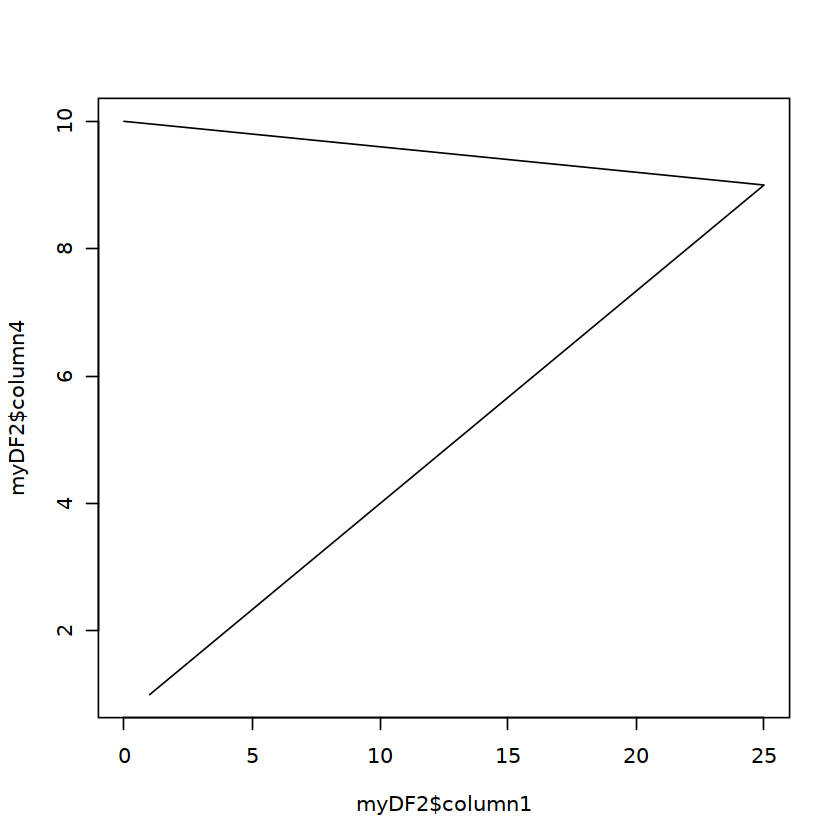

```r
plot(myDF2$column1,myDF2$column4, type = "l")
```

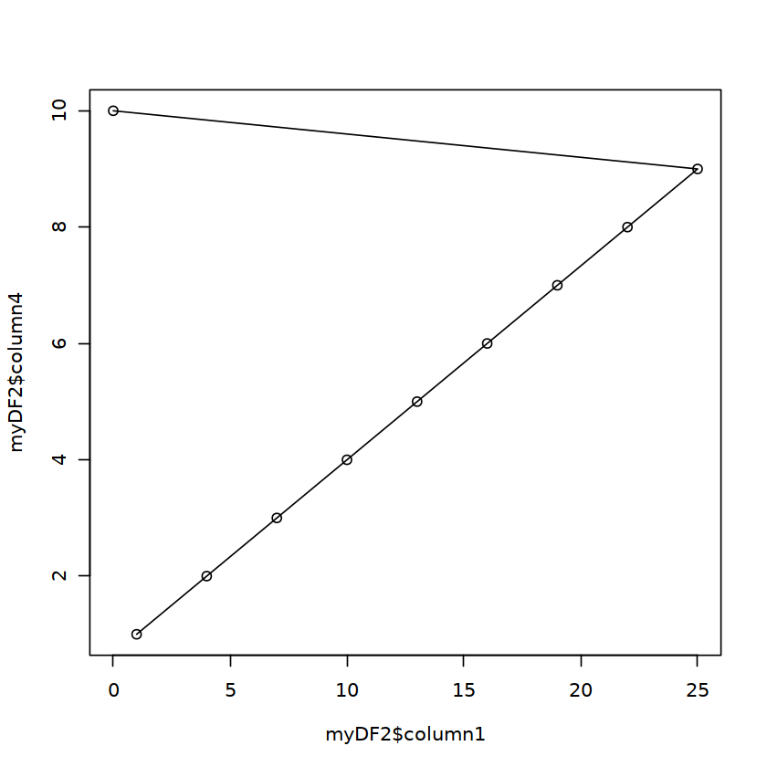

```r
plot(myDF2$column1,myDF2$column4, type = "o")
```

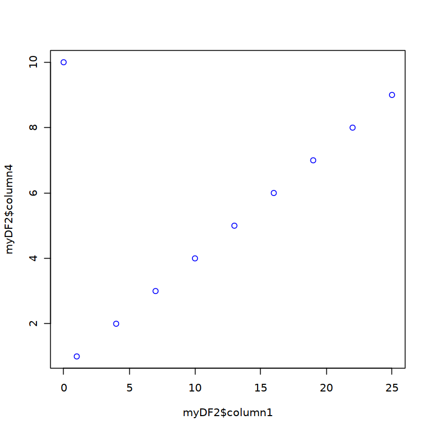

```r
plot(myDF2$column1,myDF2$column4, col="blue")
```

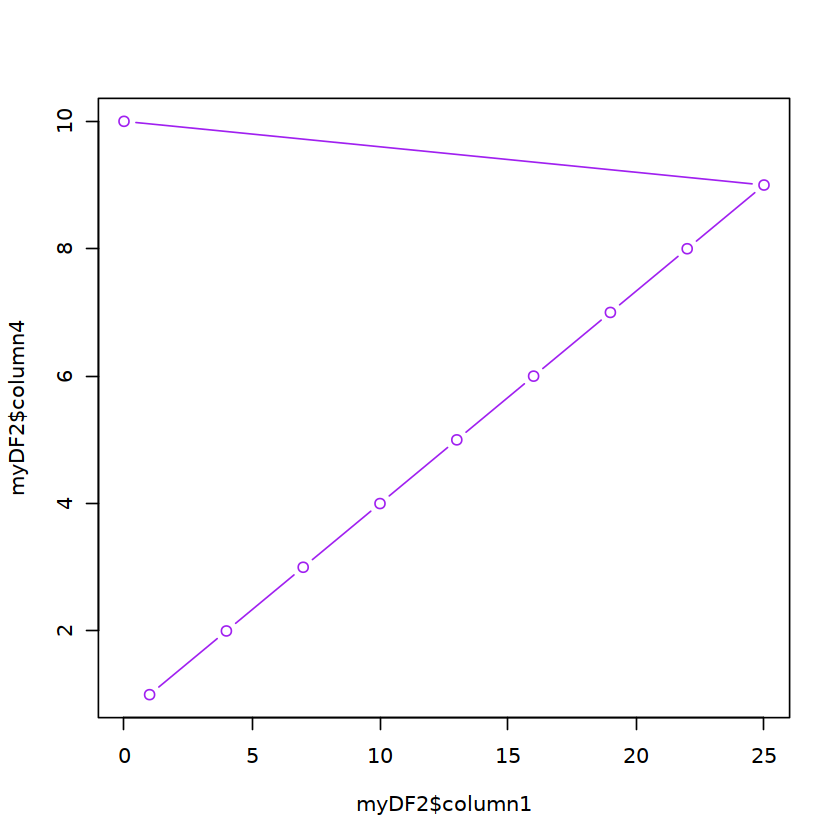

```r
plot(myDF2$column1,myDF2$column4, type="b", col="purple")
```